# QAD

17.06.2019

## Motivation - Asymetric Dependence

## Motivation

Bivariate sample:

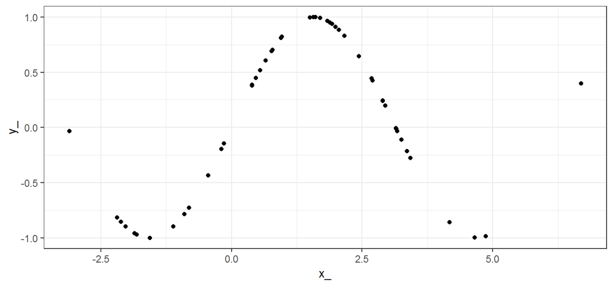

\(X \sim \mathcal{N}(1.42,2)\), \(Y = \sin(X)\).

Would it be easier to predict \(Y\) given \(X\), or \(X\) given \(Y\)?

## Motivation

Real life example: Average speed vs. Fuel consumption

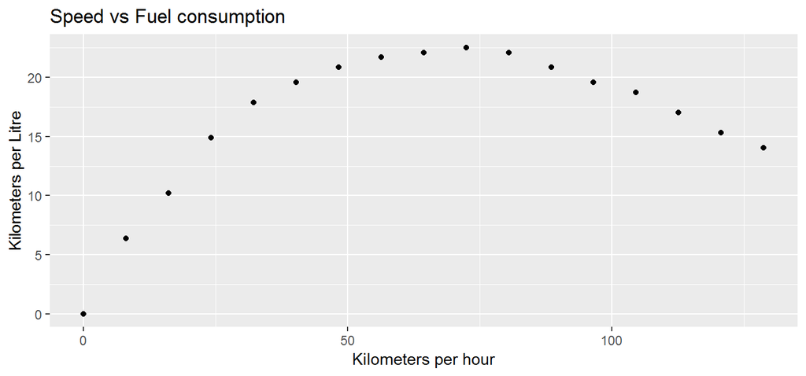

## Motivation

What is dependence between random variables \(X\) and \(Y\)?

\(X\) …result of a coin toss,  
\(Y\) …result of tossing the same coin a second time.  
-> we do not gain information about \(Y\) if we know \(X\) and vice versa.

\(X\) …result of drawing a card from a deck containing 2 cards,  
\(Y\) …result of drawing the remaining card.  
-> we know everything about \(Y\) if we know \(X\) and vice versa.

## Motivation

Why could this be a problem?

How would we usually quantify dependence?

## Motivation

Why could this be a problem?

How would we usually quantify dependence?

Correlation coefficient:

```r
cor(x_,y_)
```

```
## [1] 0.2870855
```

```r
cor(y_,x_)
```

```
## [1] 0.2870855
```

## Motivation

By definition of correlation (or covariance):

\(corr(X,Y) = corr(Y,X)\)  
The same holds true for spearman or kendall correlation.

Correlation can NOT be used as a meassure of asymmetric dependence.

## Motivation

What properties shouldan asymetric dependency meassure *q* have?

- \(q(X,Y) \in [0,1]\)
- \(q(X,Y) = 0\) iff \(X\) and \(Y\) are independent (independence)
- \(q(X,Y) = 1\) iff \(Y\) is a function of \(X\) (complete dependence)
- It may be, that \(q(X,Y) \neq q(Y,X)\).
- Scale changes should not affect the outcome.

## qad-measure - Construction:

- Start with a bivariate sample
- Use the pseudo-observations to construct the empirical copula \(E_n\).
- Aggregate \(E_n\) to the empirical checkerboard copula \(\hat{C_n}\).
- Estimate \(q(A) = 3 D_1(A,\Pi)\) via \(q(\hat{C_n}) = 3 D_1(\hat{C_n},\Pi)\).
- For sufficiently large \(n\), we have \(q(\hat{C_n}) \approx q(A)\).

## (Empirical) Copula

## Idea

We have something that links univariate and bivariate distributions and contains all the information about mutual dependency:  
Copula (lat. link").

It’s existance is guranteed by Sklar’s Theorem, therefore it makes sense to and use it for a dependency measure.

How do we get this copula from a given bivariate sample?

## Empirical copula

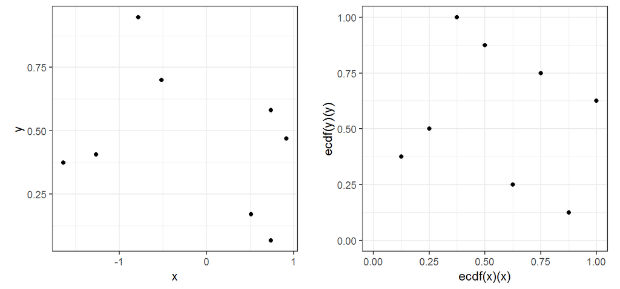

similarly to the empirical distribution:

We start with a sample \((x_1, y_1), \dots, (x_n, y_n)\) and the pseudo - observations (normalized ranks).

## Empirical copula

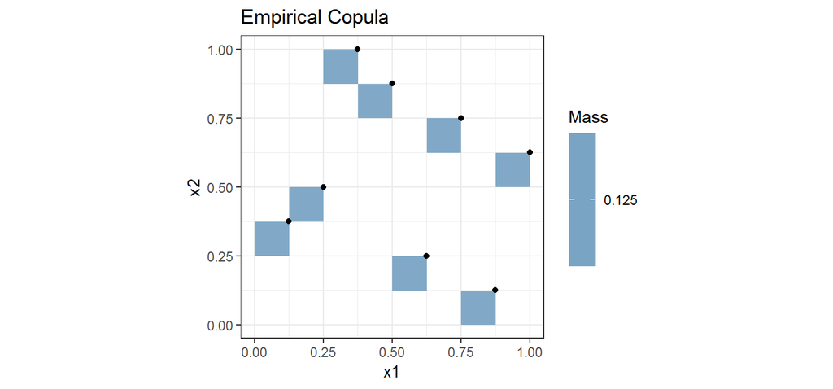

And then proceed to construct an empirical copula as shown above.

## Empirical copula of our example

Let’s compute the empirical copula for our example:

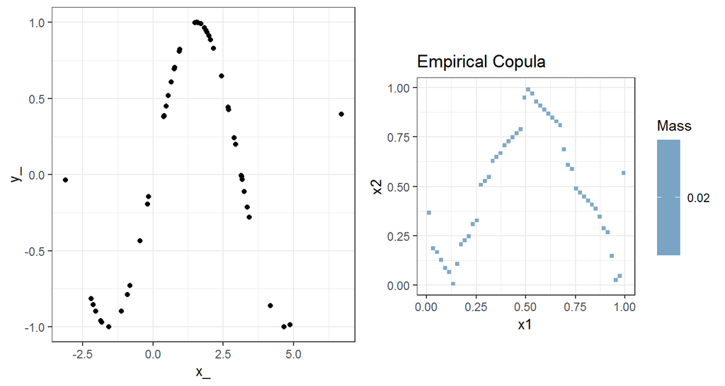

## Limitations

We would wish that the empirical copula \(E_n\) was a good estimate for the true underlying copula \(A\).

Using the aforementioned metric \(D_1\), this is not always the case.

We need to use a different estimator for \(A\).

## Empirical checkerboard copula

We aggregate the empirical copula into what we call empirical checkerboard copula.

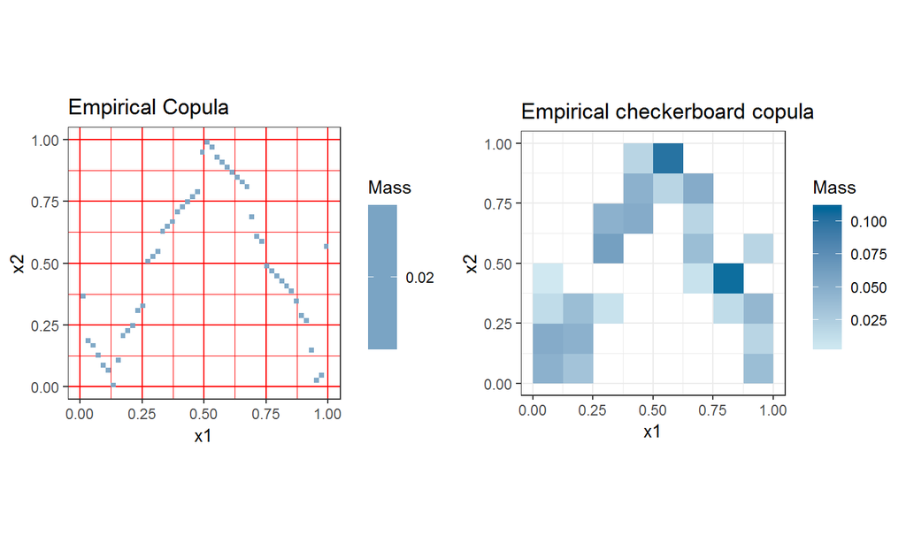

Now, not only does the checkerboard copula \(\hat{C_n}\) have nice analytical properties, it also is a good estimate for \(A\) in our metric \(D_1\), so \(D_1(\hat{C_n},A) \approx 0\) for sufficiently large \(n\).

## emp_c_copula()

The function *emp_c_copula* computes the mass-distribution of the empirical (checkerboard) copula, given a bivariate sample.

Arguments:

- X: a dataframe containing a bivariate sample
- smoothing: a logical indication whether the checkerboard copula is to be calculated
- resolution: an integer indicating the resolution of the checkerboard aggregation (the number of breaks in the grid)

## emp_c_copula()

The function *emp_c_copula* computes the mass-distribution of the empirical (checkerboard) copula, given a bivariate sample.

```r
n = 50
x = rnorm(n,0,1)
y = runif(n,0,1)
df = data.frame(x,y)
emp_cop = emp_c_copula(df,smoothing = FALSE)
emp_check_cop = emp_c_copula(df,smoothing = TRUE,resolution = 20)
```

## plot_density()

The function *plot_density* plots the density/mass of the empirical (checkerboard) copula.

Arguments:

- mass_matrix: A squared matrix containing the mass distribution (output of emp_c_copula())
- density: A logical indication whether density or mass is plotted

## plot_density()

The function plot_density allows us to visualize copulae:

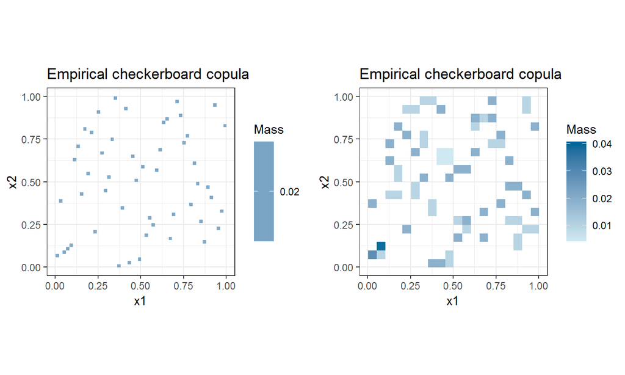

```r
plot_density(emp_cop, density=FALSE)
plot_density(emp_check_cop, density=FALSE)
```

## Exercise 1

Calculate the empirical copula – not the checkerboard copula – while having the argument *smoothing=TRUE*. (Hint: Resolution parameter)

Optional: Visualize this by plotting the pseudo observations of your generated sample into the mass-plot (Compare: slide 13,14).

Explain the differences in the following plots:

```r
n=10
df = data.frame(x = rnorm(n), y = runif(n))
emp_cop = emp_c_copula(df, smoothing = FALSE)
emp_check_cop = emp_c_copula(df, smoothing = TRUE, resolution = 20)
plot_density(emp_cop, density = FALSE)
plot_density(emp_check_cop, density = FALSE)
```

## The dependency measure

## The dependency measure

Based on a metric \(D_1\) for copulae, a dependency measure can be constructed in the following way: \[ q(A) := 3\cdot D_1(A,\Pi) \; \in [0,1] \] \(\Pi\) denotes the product copula, which stems from two completely independet RVs.

In a way, we measure the “distance” to complete independece.

## qad()

The function *qad* quantifies the asymmetric dependence of two RVs \(X\) and \(Y\). It achieves this by calculating the empirical checkerboard copula to estimate the dependency measure \(q\).

Arguments:

- X: a dataframe containing a bivariate sample in two columns.
- resolution: resolution of the emp. copula
- premutation: a logical indicating, whether a permutated \(p\)-value is computed.

## qad()

The function *qad* quantifies the asymmetric dependence of two RVs \(X\) and \(Y\). It achieves this by calculating the empirical checkerboard copula to estimate the dependency measure \(q\).

There are multiple ways to see the results of the qad calculation:

- summary(qad(X))
- coef(qad(X))
- qad(X)$results

## qad Example 1

Back to our initial example:

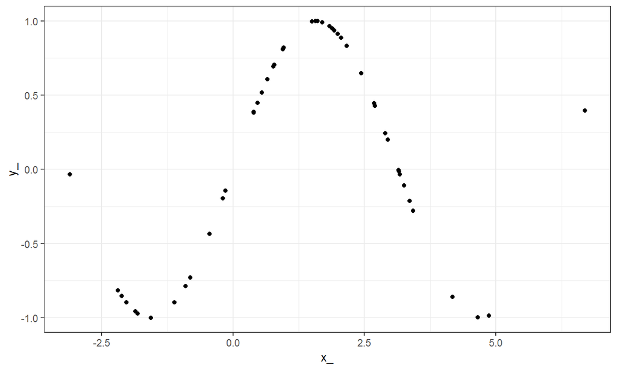

## qad Example 1

We take a look at the mutual dependencies.

```r
mod = qad(X, print = FALSE)
coef(mod, select = c("q(x1,x2)","q(x2,x1)","mean.dependence",
                     "asymmetry"))
```

```
##        q(x1,x2)        q(x2,x1) mean.dependence       asymmetry
##       0.7885979       0.4193818       0.6039898       0.3692161
```

We see that \(X\) predicts \(Y\) better than \(Y\) predicts \(X\).

## qad Example 2

```r
n = 200
x2 = runif(n,-2,4)
y2 = exp(x2)
df = data.frame(x2,y2)
model = qad(df, print = FALSE, permutation = TRUE)
model$results
```

```
##                        coef p.values
## 1        q(x1,x2) 0.9608946        0
## 2        q(x2,x1) 0.9608946        0
## 3 mean.dependence 0.9608946        0
## 4 asymmetry       0.0000000        1
```

## pairwise.qad

With the function *pairwise.qad*, we can apply the *qad* function on each pair of columns of the given dataframe. Other arguments are the same as for *qad*.

```r
n = 1000
x = runif(n,0,1)
y = x^2+rnorm(n,0,1)
z = runif(n,0,1)
df = data.frame(x,y,z)

model = pairwise.qad(df, permutation = TRUE)
```

```
## [1] "Process..."
## [1] "Process: 1 / 3"
## [1] "Process: 2 / 3"
```

## heatmap.qad

We can plot the results as a heatmap:

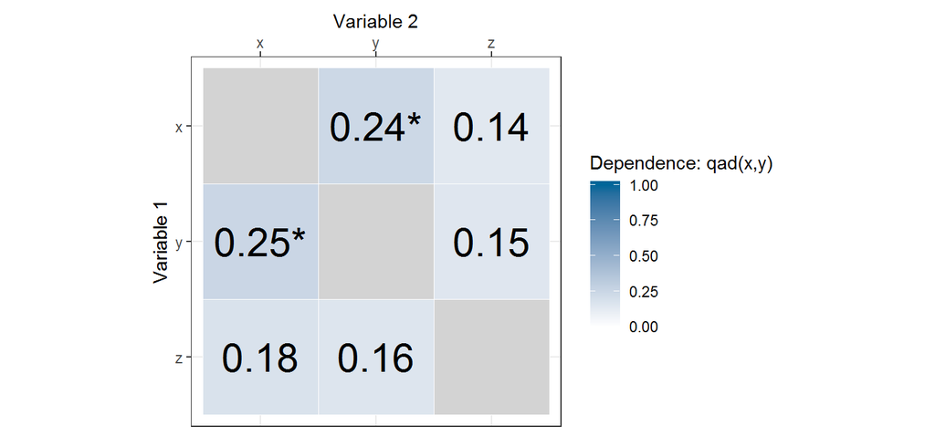

```r
heatmap.qad(model, select = "dependence", fontsize = 8,
            significance = TRUE)
```

## heatmap.qad

Arguments:

- pw_qad: the output of the function *pairwise.qad()*
- select: dependence value to be plotted: “dependence”, “mean.dependence” or “asymmetry”
- significance: logical; if p-values were calculated, marks the significant dependency values with a star
- sign.level: manually set significance level (default: 0.05)

## Exercise 2

- Download the RTR-dataset

  (via load(url(“http://www.trutschnig.net/RTR.RData”)) )

  and sample 1000 observations.
- Examine which columns could have interesting dependencies.
- Why does this not make sense for all columns?
- Visualize the dependencies for the relevant columns. Justify why you chose them.

## plot.qad

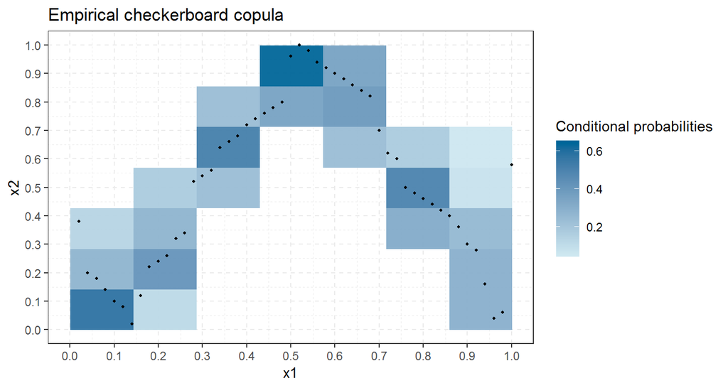

```r
plot(mod, addSample = TRUE, copula = TRUE)
```

## plot.qad

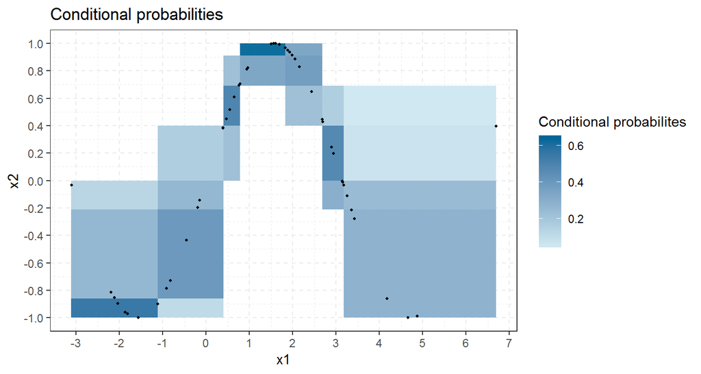

```r
plot(mod, addSample = TRUE)
```

## predict.qad

The function *predict.qad()* predicts the probabilities to end up in specific intervals given \(x\) or \(y\) values.

The prediciton can be computed in the copula or the retransformed data setting.

```r
predict(mod, values = 1.42, conditioned = "x1", nr_intervals = 5)
```

```
##      (-1,-0.79] (-0.79,-0.02] (-0.02,0.43] (0.43,0.82] (0.82,1]
## 1.42          0             0            0       0.216    0.784
```

## Exercise 3

- Create a dummy dataset: n = 100 observations of a uniformly distributed random variable and the corresponding square values.
- Create a new qad object and use the plot function to visualize the copula.
- Add the observations to the plot with the addSample parameter.
- Use the predict.qad method and sum up the probabilities for one strip (horizontal or vertical) for one value.

## cci - Conditional Confidence Interval

We can also use the qad metric to test hypothesis:

cci provides a confidence interval for independence (for the qad measure).

We can compare the qad-value to the interval boundaries and check if the null hypothesis of independence holds or has to be rejected.

## cci

We calculate our boundaries

```r
c = cci(n, alternative = "one.sided")
```

and check, whether the calculated dependence for our example lies between them.

```r
if(coef(mod, select = 'q(x1,x2)') %in% c){
 print('Accept H0')
}else{
 print('Reject H0')
}
```

## cci

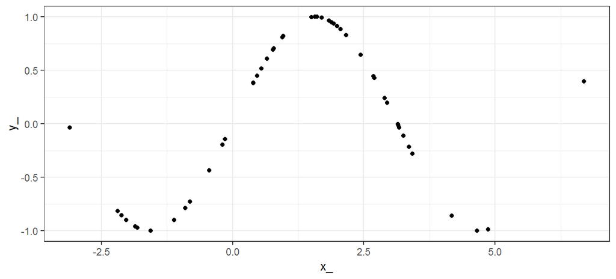

And indeed, for our example, we reject the hypothesis of independence:

```
## [1] "q(x1,x2) not in [ 0 , 0.1813481327652 ]"
## [1] "Reject H0"
```

## cci

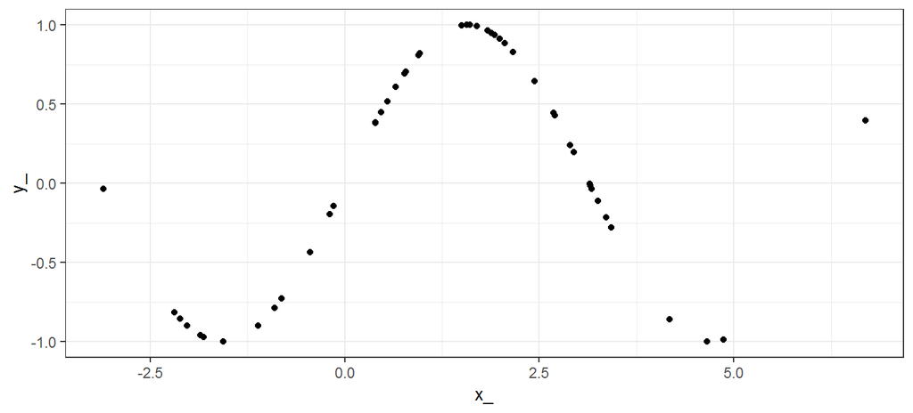

Similarly for the other direction:

```
## [1] "q(x2,x1) not in [ 0 , 0.1813481327652 ]"
## [1] "Reject H0"
```

## Final Exercise 4:

Take a look at the *attitude* dataset:

Find out the two attributes with the highest (one sided) dependency. Provide respective plots.

Are those dependencies symmetric? Argue by providing p-values for asymmetry (hint: do not to calculate the p-values for all pairs, only the chosen two)

Reject or Accept the hypothesis of independence for your chosen pairs.